# Milestone 4

Bridger Gordon

10/10/2019

## Short Description of the Plot Below

I’ve included two ggplots below – one which is the traditional geom_point scatterplot and the other is a unique ggplot package to plot the data on a US county map. First, the map of social connectedness from Lawrence County (my home county) shows that people are significantly more likely to be Facebook friends / know each other if they are in western South Dakota or eastern Wyoming + Montana and much less likely to be Facebook friends with people elsewhere in the US. This indicates the restrictions of geography/distance on social connectedness. You also can see the outline of South Dakota and how it is more likely for two people to know each other simply because they are both from South Dakota. Second, the plot of the association between the Social Connectedness Index and the racial demographics of a county. This shows there is an association between the two – people in Lawrence Co. are more likely to be friends with someone if they are from a majority-white county. There are a lot of potential explanations for this – self segregation in communities, geography (South Dakota is demographically less diverse than nationally), etc. But it is an interesting association.

[figure not shown]

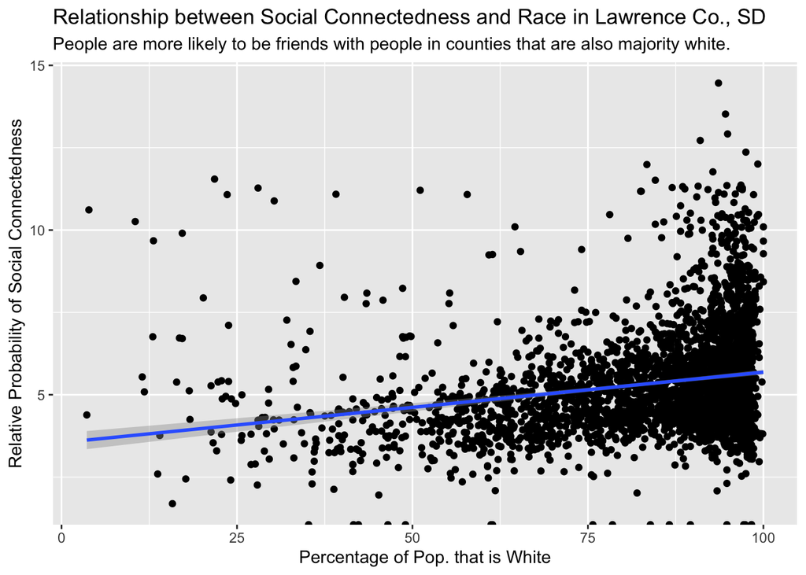